# Сборный проект: Исследование данных интернет-магазина компьютерных игр **«Стримчик»**

## Составление ортрета пользователя по региону

**Самые популярные платформы (топ-5). Опишим различия в долях продаж**

```python
# Создадим новый датафрейм для региона NA
na = top_current_platforms[['na_sales','platform', 'genre', 'rating']]
na.head()
```

|  | na_sales | platform | genre | rating |
| --- | --- | --- | --- | --- |
| 31 | 6.03 | PS4 | Shooter | unknown |
| 42 | 3.96 | PS4 | Action | M |
| 47 | 4.35 | 3DS | Role-Playing | unknown |
| 77 | 1.12 | PS4 | Sports | E |
| 87 | 2.99 | PS4 | Shooter | unknown |

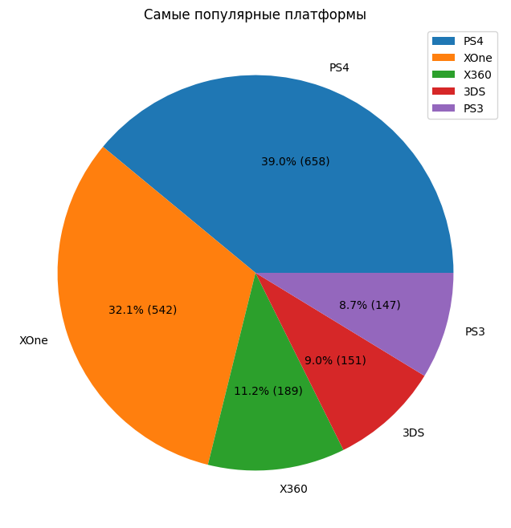

```python
# Частота встречаемости платформ в NA
(
    na.pivot_table(index='platform', values='na_sales', aggfunc='sum')
    .sort_values(by='na_sales',ascending=False).head(5)
    .plot(subplots=True,
          kind='pie',
          figsize=(10, 8),
          legend=True,
          autopct=lambda pct: f'{pct:.1f}% ({int(pct/100.*sum(na["platform"].value_counts()))})')
)

# Задание названия графика
plt.title('Самые популярные платформы')
plt.ylabel('')

# Показать график
plt.show()
```

Самой популярной консолью в регионе `NA` является `PS4`, ближайшим конкурентом по показателям выступает `XOne`. Наименее используемой платформой для игр в этом регионе является `PS3`.

```python
# Создадим новый датафрейм для региона EU
eu = top_current_platforms[['eu_sales','platform', 'genre', 'rating']]
eu.head()
```

|  | eu_sales | platform | genre | rating |
| --- | --- | --- | --- | --- |
| 31 | 5.86 | PS4 | Shooter | unknown |
| 42 | 6.31 | PS4 | Action | M |
| 47 | 3.49 | 3DS | Role-Playing | unknown |
| 77 | 6.12 | PS4 | Sports | E |
| 87 | 3.49 | PS4 | Shooter | unknown |

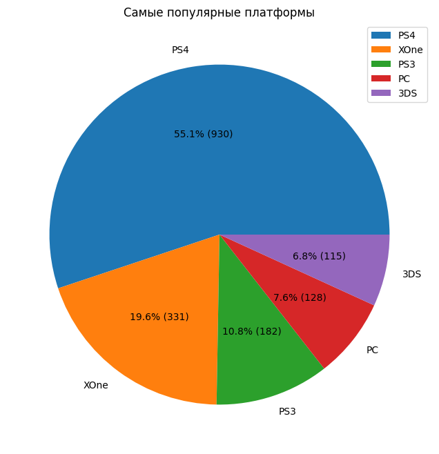

```python
# Частота встречаемости платформ в EU
(
    eu.pivot_table(index='platform', values='eu_sales', aggfunc='sum')
    .sort_values(by='eu_sales',ascending=False).head(5)
    .plot(subplots=True,
          kind='pie',
          figsize=(10, 8),
          legend=True,
          autopct=lambda pct: f'{pct:.1f}% ({int(pct/100.*sum(eu["platform"].value_counts()))})')
)

# Задание названия графика
plt.title('Самые популярные платформы')
plt.ylabel('')

# Показать график
plt.show()
```

Самой популярной консолью в регионе `EU` является `PS4`, ближайшим конкурентом по показателям выступает `XOne`. Наименее используемой платформой для игр в этом регионе является `3DS`.

```python
# Создадим новый датафрейм для региона JP
jp = top_current_platforms[['jp_sales','platform', 'genre', 'rating']]
jp.head()
```

|  | jp_sales | platform | genre | rating |
| --- | --- | --- | --- | --- |
| 31 | 0.36 | PS4 | Shooter | unknown |
| 42 | 0.38 | PS4 | Action | M |
| 47 | 3.10 | 3DS | Role-Playing | unknown |
| 77 | 0.06 | PS4 | Sports | E |
| 87 | 0.22 | PS4 | Shooter | unknown |

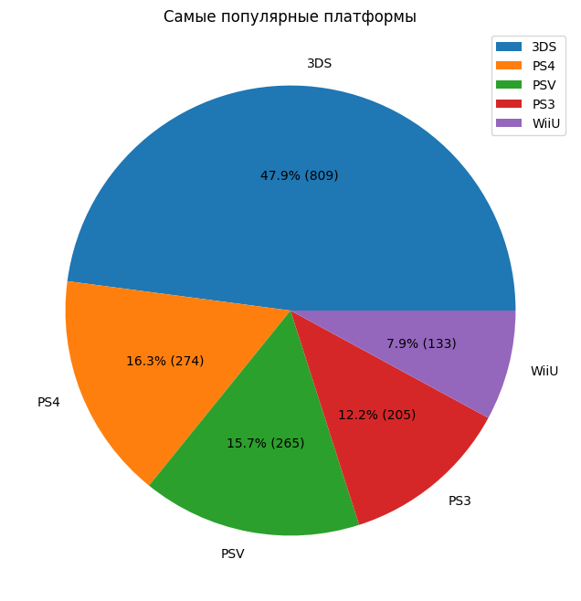

```python
# Частота встречаемости платформ в JP
(
    jp.pivot_table(index='platform', values='jp_sales', aggfunc='sum')
    .sort_values(by='jp_sales',ascending=False).head(5)
    .plot(subplots=True,
          kind='pie',
          figsize=(10, 8),
          legend=True,
          autopct=lambda pct: f'{pct:.1f}% ({int(pct/100.*sum(jp["platform"].value_counts()))})')
)

# Задание названия графика
plt.title('Самые популярные платформы')
plt.ylabel('')

# Показать график
plt.show()
```

Самой популярной консолью в регионе `JP` является `3DS`, ближайшим конкурентом по показателям выступает `PS4` и `PSV`. Наименее используемой платформой для игр в этом регионе является `WiiU`.

В `NA` и `EU` наблюдается схожая картина:

- `PS4` доминирует на обоих рынках.
- `XOne` занимает второе место по популярности.
- Однако есть различия в наименее популярных платформах: в `NA` это `PS3`, а в `EU` - `3DS`.

В `JP` иные предпочтения:

- `3DS` является лидером рынка.
- `PS4` и `PSV` делят второе место.
- `WiiU` наименее популярна.
- Рынок отдает предпочтение продукции местных производителей.